# Portfolio 1

Søren Orm Hansen

```r
library(pacman)

p_load(tidyverse, sjPlot, dplyr, nlme, ggplot2, pastecs)
```

```r
sleep <- read.csv('sleepstudy.csv')
```

###1.a: Get the data from one participant, e.g. using subset(). Make a linear regression for reaction time as a function of days of sleep deprivation, e.g. using lm(). Report the F-statistics.

```r
df <- subset(sleep, Subject == 352)
```

```r
regr1 <- lm(Reaction ~ Days, df)

summary(regr1)
```

```
Call:
lm(formula = Reaction ~ Days, data = df)

Residuals:
    Min      1Q  Median      3Q     Max
-54.695  -9.763   2.455  15.732  29.784

Coefficients:
            Estimate Std. Error t value Pr(>|t|)
(Intercept)   276.37      15.00  18.426 7.75e-08 ***
Days           13.57       2.81   4.829  0.00131 **
---
Signif. codes:  0 ‘***’ 0.001 ‘**’ 0.01 ‘*’ 0.05 ‘.’ 0.1 ‘ ’ 1

Residual standard error: 25.52 on 8 degrees of freedom
Multiple R-squared:  0.7445,    Adjusted R-squared:  0.7126
F-statistic: 23.32 on 1 and 8 DF,  p-value: 0.001307
```

###1.b: How many degrees of freedom does the relevant F-distribution have? One for the model and 8 for the residuals

###1.c: At which F-value does a regression with this distribution become statistically significant (p<0.05)?

```r
f_val <- qf(0.95, 1, 8)

f_val
```

```
[1] 5.317655
```

###1.d: Make a plot of the F-distribution.

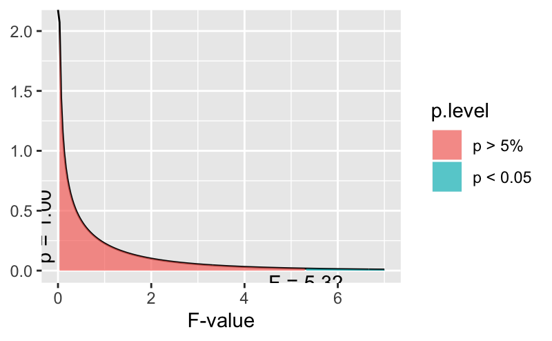

```r
dist_f(f=0, deg.f1 = 1, deg.f2 = 8, xmax=7)
```

##2.a: Find the coefficients (slope and intercept) for the regression for reaction time as a function of days of sleep deprivation (a hint for the solution: use group_by() in tidyverse or this function here: https://stat.ethz.ch/R-manual/R-devel/library/nlme/html/lmList.html, hint2: pool=FALSE)

```r
sleep$Subject <- as.factor(sleep$Subject )

sleep <- group_by(sleep, Subject)
```

```r
fit <- lmList(Reaction ~ Days | Subject, data = sleep, pool = FALSE)

fit
```

```
Call:
  Model: Reaction ~ Days | Subject
   Data: sleep

Coefficients:
```

|  | (Intercept) | Days |
| --- | --- | --- |
| 308 | 244.1927 | 21.764702 |
| 309 | 205.0549 | 2.261785 |
| 310 | 203.4842 | 6.114899 |
| 330 | 289.6851 | 3.008073 |
| 331 | 285.7390 | 5.266019 |
| 332 | 264.2516 | 9.566768 |
| 333 | 275.0191 | 9.142045 |
| 334 | 240.1629 | 12.253141 |
| 335 | 263.0347 | -2.881034 |
| 337 | 290.1041 | 19.025974 |

[output cut: 8 more lines]

##2.b: Combine both scatter plot and regression line in the same figure. You may also include all participants in one plot.

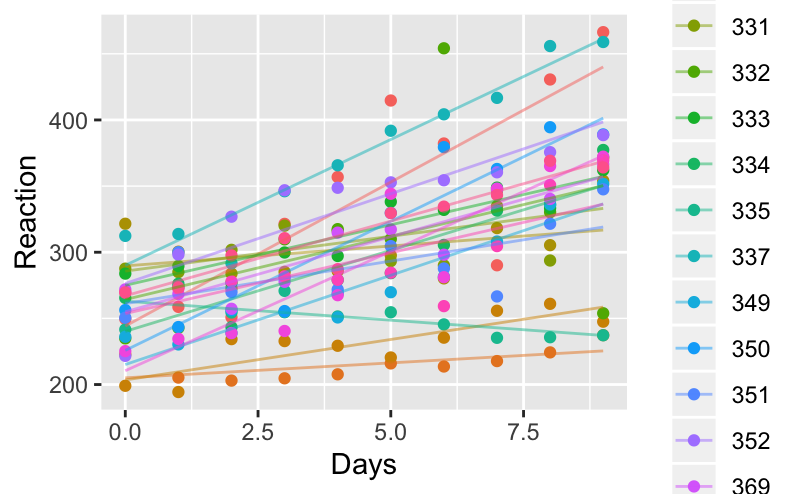

```r
ggplot(sleep, aes(Days, Reaction, color = Subject)) +
  geom_point() +
  stat_smooth(method = lm, geom='line', alpha=0.5, se=FALSE)
```

```r
  theme_minimal()
```

[output not shown]

[output cut: 312 more lines]

[output not shown]

##2.c: Collect and report the inferential statistics for each participant in a table using t-statistics, including t-value, df and p-value.

```r
sum <- summary(fit)

df_coef <- data.frame(sum[["coefficients"]])

df_coef$ID <- row.names(df_coef)

inf_stats <- data.frame(df_coef$ID,df_coef$t.value.Days, df_coef$Pr...t...Days)

colnames(inf_stats)[1] <- "ID"
colnames(inf_stats)[2] <- "t-value_Days"
colnames(inf_stats)[3] <- "p-value_Days"

inf_stats$df_model <- 1
inf_stats$df_res <- 8

inf_stats
```

| ID | t-value_Days | p-value_Days | df_model | df_res |
| --- | --- | --- | --- | --- |
| 308 | 4.137485 | 3.264657e-03 | 1 | 8 |
| 309 | 2.314848 | 4.931443e-02 | 1 | 8 |
| 310 | 4.508107 | 1.980757e-03 | 1 | 8 |
| 330 | 1.225416 | 2.552687e-01 | 1 | 8 |
| 331 | 2.041462 | 7.550229e-02 | 1 | 8 |
| 332 | 1.426926 | 1.914426e-01 | 1 | 8 |
| 333 | 6.664912 | 1.583426e-04 | 1 | 8 |
| 334 | 5.414117 | 6.352350e-04 | 1 | 8 |
| 335 | -2.297764 | 5.064731e-02 | 1 | 8 |
| 337 | 10.588367 | 5.530467e-06 | 1 | 8 |

[output cut: 8 more lines]

##2.d: How many individual participants display a statistically significant effect of sleep deprivation (p-values uncorrected for mulitple comparisons)?

##3.a: Use the slopes you found for each participant in exercise 2 as a new dataset. Test the hypothesis that the slopes are larger than zero against the null-hypothesis that the slopes are zero (i.e. no differences in response time exist as a function of time).

```r
coefs <- coef(fit)

coefs <- select(coefs, Days)

coefs$null <- 0

t.test(coefs$Days, alternative = 'greater')
```

```
    One Sample t-test

data:  coefs$Days
t = 6.7715, df = 17, p-value = 1.632e-06
alternative hypothesis: true mean is greater than 0
95 percent confidence interval:
 7.778221      Inf
sample estimates:
mean of x
 10.46729
```

##3.b: Justify your use of test statistics.

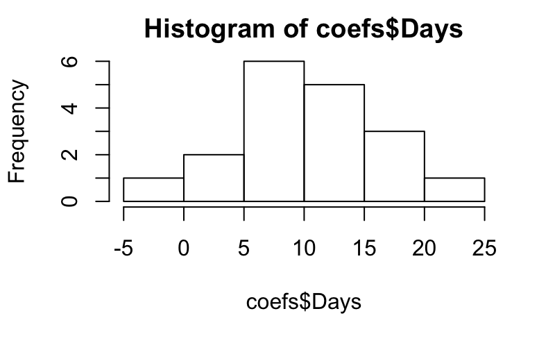

```r
hist(coefs$Days)
```

```r
round(stat.desc(coefs$Days, norm = T, basic = F), digits = 4)
```

```
      median         mean      SE.mean CI.mean.0.95          var      std.dev     coef.var
     10.4324      10.4673       1.5458       3.2613      43.0103       6.5582       0.6265
    skewness     skew.2SE     kurtosis     kurt.2SE   normtest.W   normtest.p
     -0.0653      -0.0609      -0.8207      -0.3954       0.9788       0.9369
```

We used a one sample t-test to test whether the slopes are signigicantly larger that 0. The data is normally distributed (the shape of the histogram, the Shapiro Wilks test for normality, and the skew.2SE and kurt.2SE indicates normality).

##3.c: Report inferential statistics.

##3.d: Make a plot with the mean reaction time and standard errror bars for each day across participants and plot the averaged regression line in the same figure.

```r
reg_line <- coef(lm(Reaction ~ Days, data = sleepstudy))
```

[output not shown]

[output not shown]